# Study 2 analysis: initial learning tasks

George Kinnear

19/08/2021

```r
library(tidyverse)

#Plots
library(ggplot2)
library(patchwork) # for combining plots
library(ggtext) # for markdown in plots
library(latex2exp) # for formatting latex in plot captions

# For Bayesian stats:
library(bayestestR)
#library(insight)
#library(see)
library(rstanarm)
library(tidybayes)
#library(BayesFactor)
ci_width = 0.95  # Use 95% HDIs
set.seed(20210518)

# Tables
library(knitr)
library(kableExtra)
basic_kable = function(df, ...) {
  df %>%
    kable(...) %>%
    kable_styling(bootstrap_options = "striped", full_width = F)
}

# Plot styling
heathers = c("#00b3c3","#e51c24","#016637","#fcb123")
heathers = c("#87005a", "#c66005","#016637","#fcb123")
groupcolours = c("C-CG" = heathers[1],
                 "C-GC" = "#6f004a", # darker heathers1
                 "G-CG" = heathers[2],
                 "G-GC" = "#a34e03" # darker heathers2
                 )
four_groups = c("CCG", "CGC", "GCG", "GGC")
theme_set(theme_minimal())
```

```r
question_marks = read_csv("data-clean/study2/FAC_LGE2-tasks.csv") %>%
  select(question_name, marks_available)

participants <- read_csv("data-clean/study2/participants.csv")

attempt_data_all = read_rds("data-clean/FAC_LGE2-attempt_data.rds") %>%
  # tidy up group names
  mutate(
    group = str_replace(group, "Group ", ""),
    overall_group = str_sub(group, 1, 1)
  ) %>%
  mutate(
    quiz = case_when(
      question_name %in% c("FarC1", "FarC2") ~ "FT",
      str_detect(question_name, "Mid") ~ "S2",
      TRUE ~ "S1"
    )
  ) %>%
  left_join(question_marks, by = "question_name") %>%
  mutate(
    # default to 1 mark per question if not specified
    marks_available = replace_na(marks_available, 1),
    marks_attained = fraction * marks_available,
    # check the time of the attempt to see if it was before the end of the study
    attempt_time = lubridate::as_datetime(timecreated),
    during_study = attempt_time < lubridate::ymd("2020-11-27")
  )
```

# Item performance

```r
first_attempts = attempt_data_all %>%
  filter(during_study == TRUE) %>%
  filter(attempt_number == 1) %>%
  group_by(quiz, question_name, username) %>%
  select(quiz, question_name, username, fraction, attempt_number) %>%
  ungroup()

last_attempts = attempt_data_all %>%
  filter(during_study == TRUE) %>%
  group_by(quiz, question_name, username) %>%
  # select the final attempt
  top_n(n = 1, wt = attempt_number) %>%
  select(quiz, question_name, username, fraction, attempt_number) %>%
  ungroup()

best_attempts = attempt_data_all %>%
  filter(during_study == TRUE) %>%
  group_by(quiz, question_name, username) %>%
  # select the best attempt
  top_n(n = 1, wt = fraction) %>%
  slice(1) %>%
  select(quiz, question_name, username, fraction, attempt_number) %>%
  ungroup()

attempts_summary = bind_rows(
  list("first" = first_attempts,
       "last" = last_attempts,
       "best" = best_attempts),
  .id = "attempt_type"
)

attempts_summary_stats = attempts_summary %>%
  filter(attempt_type != "best") %>%
  group_by(quiz, question_name, attempt_type) %>%
  summarise(
    mean_score = mean(fraction, na.rm = TRUE),
    null_response = sum(is.na(fraction)) / n(),
    n = n(),
    .groups = "drop"
  ) %>%
  ungroup() %>%
  mutate(
    plot_order = case_when(
      str_detect(question_name, "^C|^G") ~ "1. Learning",
      str_detect(question_name, "Near") ~ "2. Near",
      str_detect(question_name, "Mid") ~ "3. Mid",
      str_detect(question_name, "Far") ~ "4. Far"
    )
  )
```

This shows the mean score on each of the items:

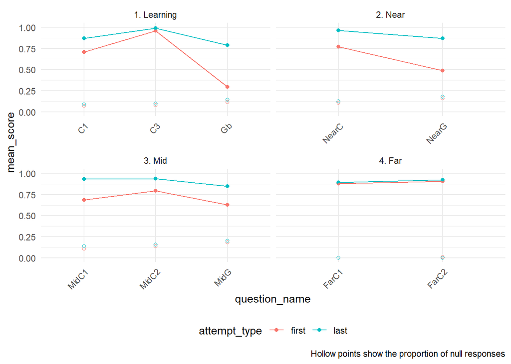

```r
attempts_summary_stats %>%
  ggplot(aes(x = question_name,
             y = mean_score,
             colour = attempt_type,
             group = attempt_type)) +
  geom_point() +
  geom_line() +
  geom_point(data = attempts_summary_stats,
             mapping = aes(x = question_name,
                 y = null_response),
             shape = 1) +
  facet_wrap(~plot_order, scales = "free_x") +
  theme_minimal() +
  theme(axis.text.x = element_text(angle = 45, hjust = 1),
        legend.position = "bottom") +
  ylim(c(0,1)) +
  labs(caption = "Hollow points show the proportion of null responses")
```

## Initial learning task: Classification

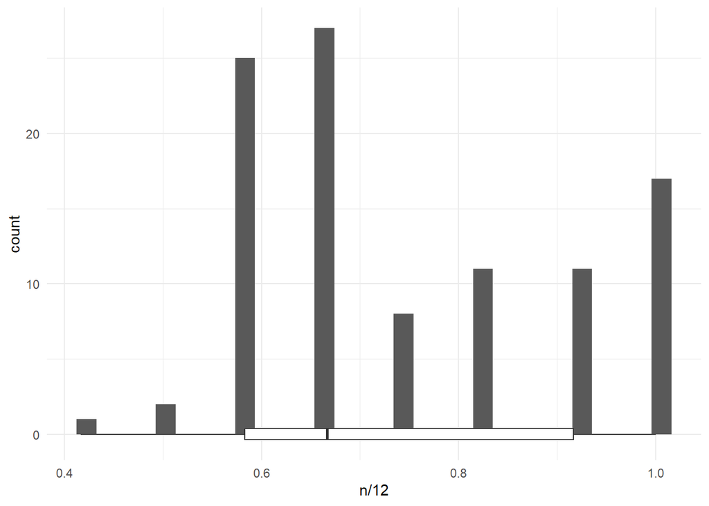

```r
per_student_C_marks <- attempt_data_all %>%
  filter(str_detect(question_name, "^C"),
         attempt_number == 1,
         !is.na(marks_attained)) %>%
  select(question_name, username, marks_attained) %>%
  group_by(username) %>%
  tally(marks_attained)

per_student_C_marks %>%
  ggplot(aes(x = n/12)) +
  geom_histogram() +
  geom_boxplot()
```

```r
per_student_C_marks %>%
  summarise(mean = mean(n), mean_pc = mean/12*100, .groups = "drop") %>%
  basic_kable()
```

| mean | mean_pc |
| --- | --- |
| 8.970588 | 74.7549 |

```r
# Separate the raw response data into details of the 10 different sub-parts
# - extract the details of which sub-part is which of the Alcock & Simpson items (item_part)
# - plus the corresponding response (ans_part) and score (score_part) for each sub-part
responses_C1 <- attempt_data_all %>%
  filter(question_name == "C1",
         attempt_number == 1,
         !is.na(marks_attained)) %>%
  select(group, username, questionsummary, responsesummary, marks_attained) %>%
  # pick out the responses to each part
  # STACK output uses [score] to separate the responses to each part; use NA to discard the final bit that is about the PRTs
  separate(col = responsesummary,
           into = c(paste0("ans_part", c(1:10)), NA),
           sep = "\\[score\\]; ",
           remove = FALSE) %>%
  mutate(across(contains("ans"), ~ str_remove(., ".*: "))) %>%
  # pick out the scores for each part (this time discarding the first bit that holds the responses)
  separate(col = responsesummary,
           into = paste0("score_part", c(0:10)),
           sep = "\\| prt") %>%
  select(-score_part0) %>%
  mutate(across(contains("score"), ~ str_remove(., ";.*"))) %>%
  mutate(across(contains("score"), ~ str_remove(., ".*-.*-"))) %>%
  mutate(questionsummary = str_remove_all(questionsummary, "\\[|\\]")) %>%
  separate(col = questionsummary,
           into = paste0("item_part", c(1:10)),
           sep = ",")

responses_C3 <- attempt_data_all %>%
  filter(question_name == "C3",
         attempt_number == 1,
         !is.na(marks_attained)) %>%
  select(group, username, questionsummary, responsesummary, marks_attained) %>%
  # pick out the responses to each part
  separate(col = responsesummary,
           into = c(paste0("ans_part", c(14:15)), NA),
           sep = "\\[score\\]; ",
           remove = FALSE) %>%
  mutate(across(contains("ans"), ~ str_remove(., ".*: "))) %>%
  # pick out the scores for each part (this time discarding the first bit that holds the responses)
  separate(col = responsesummary,
           into = c(NA,paste0("score_part", c(14:15))),
           sep = "\\| prt") %>%
  mutate(across(contains("score"), ~ str_remove(., ";.*"))) %>%
  mutate(across(contains("score"), ~ str_remove(., ".*-.*-"))) %>%
  mutate(questionsummary = str_remove_all(questionsummary, "\\[|\\]")) %>%
  separate(col = questionsummary,
           into = paste0("item_part", c(14:15)),
           sep = ",") %>%
  # make the item numbers 14,15 instead of 1,2
  rowwise() %>%
  mutate(across(contains("item_part"), ~ as.character(sum(c(as.numeric(.x), 13)))))

responses_C_long = responses_C1 %>%
  select(-marks_attained) %>%
  full_join(responses_C3 %>% select(-marks_attained), by = c("group", "username")) %>%
  pivot_longer(
    # take variables of the form STUFF_partN and separate
    # into a column for each kind of STUFF and store the
    # values of N in a column called "part"
    contains("part"),
    names_to = c(".value", "part"),
    names_sep = "_part"
  ) %>%
  mutate(score = if_else(score == "T", 1, 0)) %>%
  mutate(score = replace_na(score, 0),
         item = as.integer(item),
         item = as.factor(item),
         ans = str_remove_all(ans, '\\"| '),
         ans = na_if(ans, ""))
```

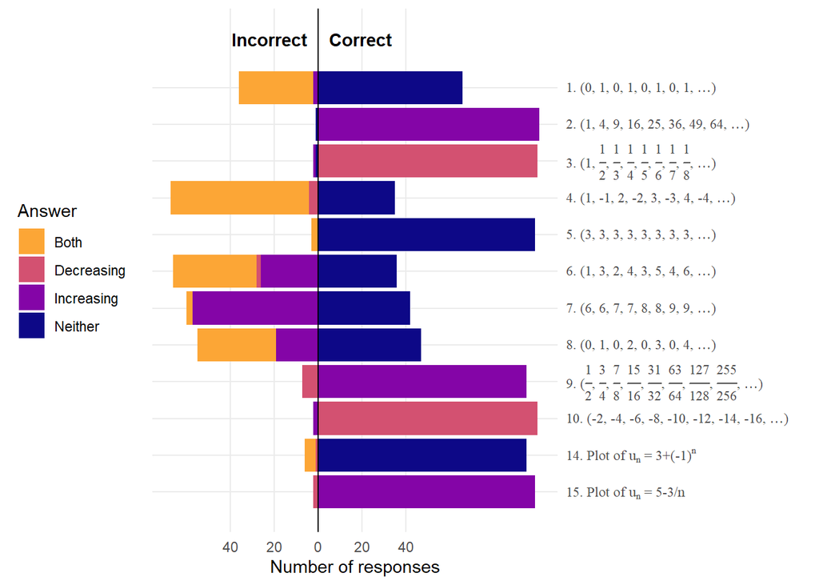

```r
responses_C_summary = responses_C_long %>%
  group_by(item, ans) %>%
  summarise(
    count = n(),
    .groups = "drop"
  ) %>%
  arrange(item) %>%
  group_by(item) %>%
  mutate(
    correct_ans = case_when(
      item %in% c(2,9,11,13,15) & ans == "Increasing" ~ "Correct",
      item %in% c(3,10) & ans == "Decreasing" ~ "Correct",
      item %in% c(1,4,5,6,7,8,12,14) & ans == "Neither" ~ "Correct",
      TRUE ~ "Incorrect"
    ),
    signed_count = if_else(correct_ans == "Correct", count, -count),
    signed_prop = signed_count / sum(count*!is.na(ans))
  ) %>%
  drop_na()

# library(latex2exp) needed here
windowsFonts(Times=windowsFont("TT Times New Roman"))
responses_C_summary %>%
  mutate(item = as.numeric(item)) %>%
  ggplot(aes(x = item, y = signed_count, fill = ans)) +
  geom_bar(position = "stack", stat = "identity") +
  geom_hline(yintercept = 0) +
  #scale_fill_viridis_d("Answer", end = 0.85, option = "viridis") +
  scale_fill_viridis_d("Answer", option = "plasma", end = 0.8, direction = -1) +
  #scale_fill_grey("Answer", end = 0.8) +
  scale_y_continuous("Number of responses", labels = abs, breaks = seq(-40, 40, 20)) +
  scale_x_reverse(
    position = "top",
    breaks = c(1:12),
    minor_breaks = c(1:12),
    labels = c(
      "1" = parse(text = TeX("1. (0,1,0,1,0,1,0,1,\\ldots)")),
      "2" = parse(text = TeX("2. (1, 4, 9, 16, 25, 36, 49, 64,\\ldots)")),
      "3" = parse(text = TeX("3. (1,\\frac{1}{2},\\frac{1}{3},\\frac{1}{4},\\frac{1}{5},\\frac{1}{6},\\frac{1}{7},\\frac{1}{8},\\ldots)")),
      "4" = parse(text = TeX("4. (1,-1,2,-2,3,-3,4,-4,\\ldots)")),
      "5" = parse(text = TeX("5. (3,3,3,3,3,3,3,3,\\ldots)")),
      "6" = parse(text = TeX("6. (1, 3, 2, 4, 3, 5, 4, 6,\\ldots)")),
      "7" = parse(text = TeX("7. (6, 6, 7, 7, 8, 8, 9, 9,\\ldots)")),
      "8" = parse(text = TeX("8. (0, 1, 0, 2, 0, 3, 0, 4,\\ldots)")),
      "9" = parse(text = TeX("9. (\\frac{1}{2}, \\frac{3}{4}, \\frac{7}{8}, \\frac{15}{16}, \\frac{31}{32}, \\frac{63}{64}, \\frac{127}{128}, \\frac{255}{256},\\ldots)")),
      "10" = parse(text = TeX("10. (-2,-4,-6,-8,-10,-12,-14,-16,\\ldots)")),
      "11" = parse(text = TeX("14. Plot of u_n = 3+(-1)^n")),
      "12" = parse(text = TeX("15. Plot of u_n = 5-3/n"))
    )
  ) +
  labs(x = "") +
  coord_flip() +
  expand_limits(y = c(-40,40)) +
  annotate("text", x = -0.5, y = 5, label = "Correct", fontface = "bold", hjust = "left", vjust = "top") +
  annotate("text", x = -0.5, y = -5, label = "Incorrect", fontface = "bold", hjust = "right", vjust = "top") +
  theme(axis.text.y = element_text(family="Times"),
        panel.grid.minor.x = element_blank(),
        legend.position = "left")
```

```r
ggsave("figs/FIG_study2_responses_C.pdf", width = 18, height = 12, units = "cm")


options(knitr.kable.NA = '')
responses_C_summary %>%
  pivot_wider(
    id_cols = item,
    names_from = ans,
    values_from = count
  ) %>%
  basic_kable(
    #format = "latex", booktabs = T
  )
```

| item | Both | Increasing | Neither | Decreasing |
| --- | --- | --- | --- | --- |
| 1 | 34 | 2 | 66 |  |
| 2 |  | 101 | 1 |  |
| 3 |  | 1 | 1 | 100 |
| 4 | 63 |  | 35 | 4 |
| 5 | 3 |  | 99 |  |
| 6 | 38 | 26 | 36 | 2 |
| 7 | 3 | 57 | 42 |  |
| 8 | 36 | 19 | 47 |  |
| 9 |  | 95 |  | 7 |
| 10 |  | 2 |  | 100 |
| 14 | 5 |  | 95 | 1 |
| 15 |  | 99 |  | 2 |

## Initial learning task: Example generation

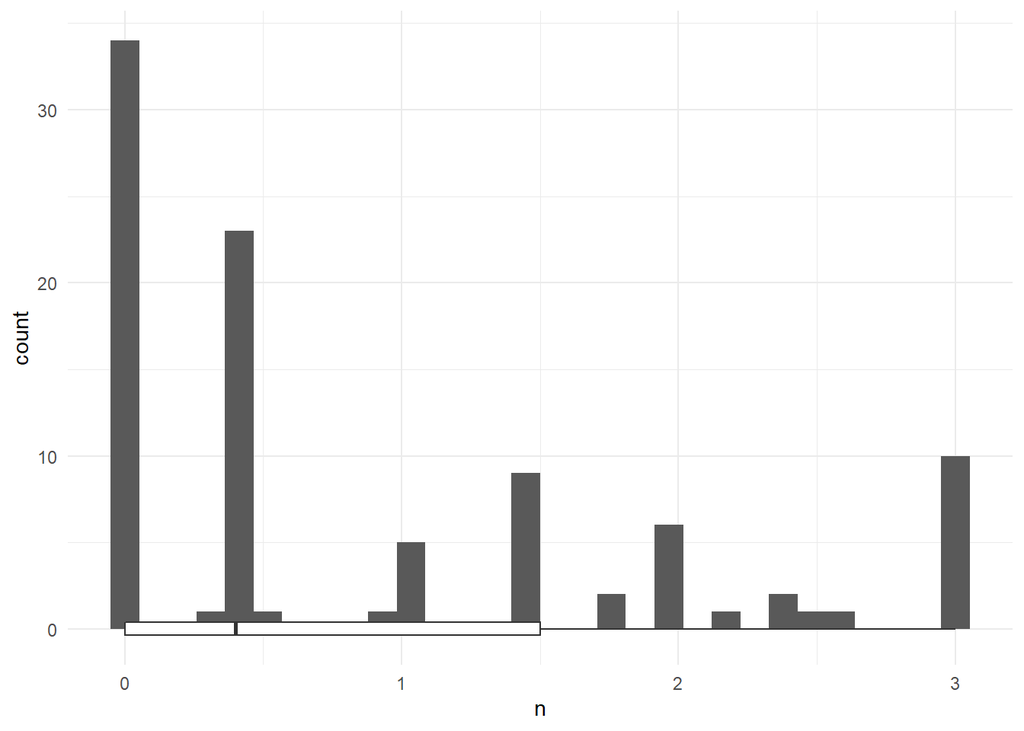

```r
per_student_G_marks <- attempt_data_all %>%
  filter(str_detect(question_name, "^G"),
         attempt_number == 1,
         !is.na(marks_attained)) %>%
  select(question_name, username, marks_attained) %>%
  group_by(username) %>%
  tally(marks_attained)

per_student_G_marks %>%
  ggplot(aes(x = n)) +
  geom_histogram() +
  geom_boxplot()
```

```r
per_student_G_marks %>%
  summarise(mean = mean(n), mean_pc = mean/3*100, .groups = "drop") %>%
  basic_kable()
```

| mean | mean_pc |
| --- | --- |
| 0.8938144 | 29.79381 |

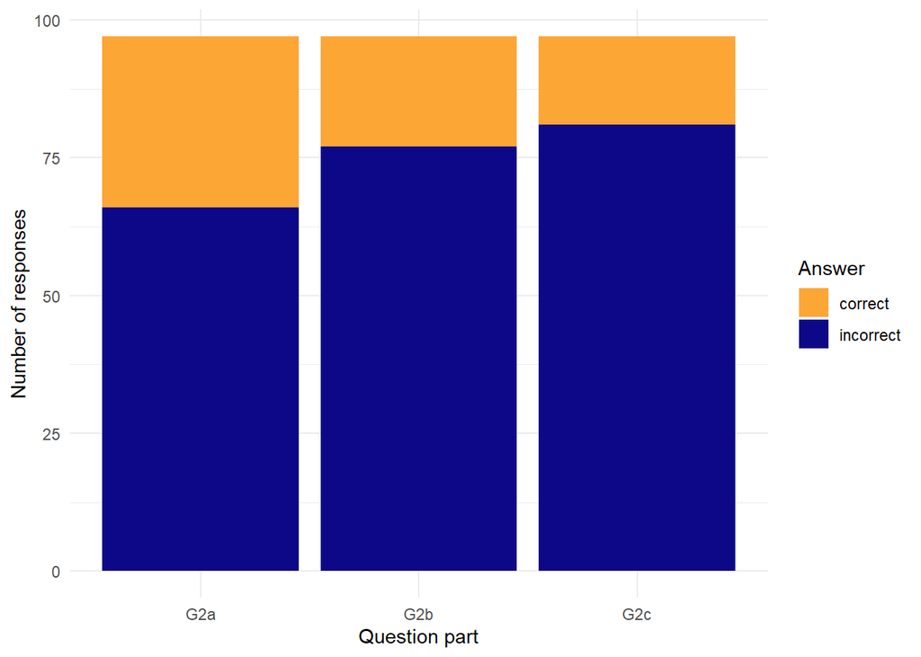

```r
responses_G <- attempt_data_all %>%
  filter(
    str_detect(question_name, "^G"),
    attempt_number == 1,
    !is.na(marks_attained)
  ) %>%
  select(group, username, question_name, questionsummary, responsesummary, marks_attained) %>%
  # pick out the various answers - str_match_all returns a matrix, which we have to wrangle a bit
  mutate(ans_bits = str_match_all(responsesummary, "(ans[^:]*): ([^;]*)(?=\\[score\\];)")) %>%
  mutate(ans_bits = map(ans_bits, ~ tibble(part = .x[,2], response = .x[,3]))) %>%
  unnest(ans_bits) %>%
  # construct a simplified name for each question part
  mutate(
    G_part = case_when(
      # Convert Gb ans3 to G2c etc
      question_name == "Gb" ~ paste0("G2", letters[parse_number(part)]),
    ),
    fully_correct = case_when(
      G_part == "G2a" ~ str_detect(responsesummary, "prt1-1-T"),
      G_part == "G2b" ~ str_detect(responsesummary, "prt2-4-T"),
      G_part == "G2c" ~ str_detect(responsesummary, "prt3-4-T") & str_detect(responsesummary, "prt3-5-T"),
    ),
    relevant_prt = case_when(
      # pick out the PRT trace that is relevant to each part, i.e. that grades that answer
      is.na(G_part) ~ NA_character_,
      question_name %in% c("Ga", "Gb", "Gc") ~ str_match_all(responsesummary, str_glue("prt{parse_number(part)}: [^;]*(?=; |$)")) %>% as.character(),
      TRUE ~ str_match_all(responsesummary, str_glue("prt1: [^;]*(?=; |$)")) %>% as.character()
    )
  ) %>%
  select(-contains("summary"))

responses_G_summary <- responses_G %>%
  janitor::tabyl(G_part, fully_correct) %>%
  select(part = G_part, incorrect = "FALSE", correct = "TRUE")

responses_G_summary %>%
  filter(!is.na(part)) %>%
  pivot_longer(cols = contains("correct"), names_to = "type", values_to = "count") %>%
  ggplot(aes(x = part, y = count, fill = type)) +
  geom_bar(position = "stack", stat = "identity") +
  scale_fill_viridis_d("Answer", option = "plasma", end = 0.8, direction = -1) +
  scale_y_continuous("Number of responses") +
  labs(x = "Question part")
```

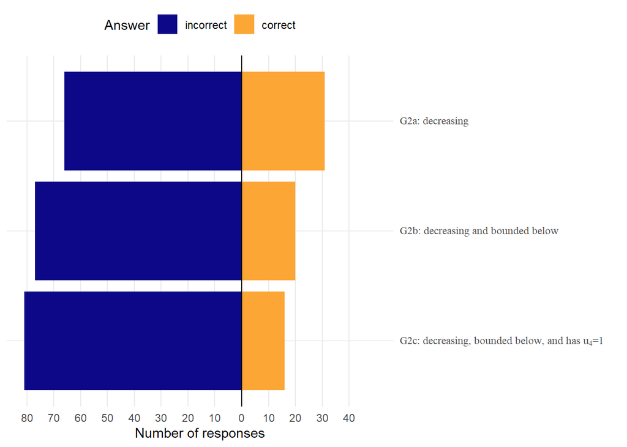

```r
responses_G_summary %>%
  filter(!is.na(part)) %>%
  mutate(part = fct_rev(part)) %>%
  pivot_longer(cols = contains("correct"), names_to = "type", values_to = "count") %>%
  mutate(signed_count = if_else(type == "correct", count, -count)) %>%
  ggplot(aes(x = part, y = signed_count, fill = type)) +
  geom_bar(position = "stack", stat = "identity") +
  geom_hline(yintercept = 0) +
  #scale_fill_viridis_d("Answer", end = 0.85, option = "viridis") +
  scale_fill_viridis_d("Answer", option = "plasma", end = 0.8, direction = -1, guide = guide_legend(reverse = TRUE)) +
  #scale_fill_grey("Answer", end = 0.8) +
  scale_y_continuous("Number of responses", labels = abs, breaks = seq(-80, 40, 10)) +
  scale_x_discrete(
    position = "top",
    labels = c(
      "G2a" = "G2a: decreasing",
      "G2b" = "G2b: decreasing and bounded below",
      "G2c" = parse(text = TeX("G2c: decreasing, bounded below, and has $u_4=1$"))
    )
  ) +
  labs(x = "") +
  coord_flip() +
  expand_limits(y = c(-50,50)) +
  #annotate("text", x = 13.2, y = 5, label = "Correct", fontface = "bold", hjust = "left", vjust = "top") +
  #annotate("text", x = 13.2, y = -5, label = "Incorrect", fontface = "bold", hjust = "right", vjust = "top") +
  theme(axis.text.y = element_text(family="Times"),
        panel.grid.minor.x = element_blank(),
        strip.text.y = element_blank(),
        legend.position = "top") +
  facet_grid(rows = vars(str_sub(part, start = 1, end = 2)), scales = "free", space = "free")
```

```r
ggsave("figs/FIG_study2_responses_G.pdf", width = 18, height = 8, units = "cm")

responses_G_summary %>%
  filter(!is.na(part)) %>%
  basic_kable()
```

| part | incorrect | correct |
| --- | --- | --- |
| G2a | 66 | 31 |
| G2b | 77 | 20 |
| G2c | 81 | 16 |

Summary of responses to G2:

```r
responses_G %>%
  group_by(G_part, fully_correct, relevant_prt, response) %>%
  tally() %>%
  group_by(G_part, fully_correct, relevant_prt) %>%
  summarise(
    num_responses = sum(n),
    responses = paste0(str_trim(response), collapse = "; "),
    .groups = "drop"
  ) %>%
  basic_kable() %>%
  collapse_rows(columns = 1:2, valign = "top")
```

| G_part | fully_correct | relevant_prt | num_responses | responses |
| --- | --- | --- | --- | --- |
| G2a | FALSE | prt1: # = 0 \| ATAlgEquiv_SA_not_logic. \| prt1-1-F \| ATAlgEquiv_SA_not_logic. \| prt1-2-F | 8 | (u_(n-1)) - 1; u*n-2; u_(n-1)-1; u_(n-1) - 1; u_(n+1)-2; u_(n+1) |
| G2a | FALSE | prt1: # = 0 \| prt1-1-F \| ATLogic_True. \| prt1-2-T | 58 | -1; -1*a_n; -u_n; (1/2)*u_n-1; 0; 1-u_n; 1; 1/2*n; 1/u_n; 2*n; 2*n+1; 3; 4; 5; 6; a_n-1; n-1; n-2; n^2+1; u-1; u_n-1; u_n-1 -c; u_n-5; u2 |
| G2a | TRUE | prt1: # = 1 \| ATLogic_True. \| prt1-1-T | 31 | -2*n; -4*n; -5*n; -n-1; -n; -n*3; -n+1; (-n-1); 1-n; 1/n; 2*n^-1; 3/n; 4-4*(n-1); n-2*n; n^-1 |
| G2b | FALSE | prt2: # = 0 \| ATAlgEquiv_SA_not_logic. \| prt2-1-F \| ATAlgEquiv_SA_not_logic. \| prt2-2-F | 9 | (-1)^(-n); (-1/2)^n; (-n)^n; (u(n+1))/2; (u_(n+1)) + 1; n^(1/n); sqrt(u_(n-1)-1); u_(n-1)/10; u_(n+1) |
| G2b | FALSE | prt2: # = 0 \| prt2-1-F \| ATLogic_True. \| prt2-2-T | 57 | -((u_n)^2); -1; -1*a_n; -m; (-1)^2-10; (-1/n); (1)^n; 0; 1; 2; 2*n-1/5*n; 2*u_n; 2^n; 3; 4; 5; 6; 7; 8; a_n-2; M+u_n-1; n-1; n/2; n+1; n+2; sqrt(u_n); u-1; u; u_m-1; u_n-1; u_n; u_n+1 |
| G2b | FALSE | prt2: # = 0.5 \| ATLogic_True. \| prt2-1-T \| prt2-3-F \| prt2-4-F | 11 | -(n^2); -2^n; -5*n+2; -6*n^2; -e^n; -ln(n); -n; 1-n; 1-n^2; 100-n^2; n-2*n |
| G2b | TRUE | prt2: # = 1 \| ATLogic_True. \| prt2-1-T \| prt2-3-F \| ATLogic_True. \| prt2-4-T | 20 | 1/5^n; 1/n; 1/n^2; 2/n; 24*(1/n); 5/n; n^-1 |
| G2c | FALSE | prt3: # = 0 \| prt3-5-F \| ATAlgEquiv_SA_not_logic. \| prt3-1-F \| ATAlgEquiv_SA_not_logic. \| prt3-2-F | 2 | (-1/2)^n+1/16; u_(n+1) |
| G2c | FALSE | prt3: # = 0 \| prt3-5-F \| prt3-1-F \| ATLogic_True. \| prt3-2-T | 44 | -1^n; -3; (u_n-3)^2; 0; 16*(1/4); 2; 22222; 3; 3*n; 4; 4*n-1; 5; 6; 8; e^(1/4*x); i; M+u_n-1; n-1/n; n; u-3; u_n-1; u_n; wh_at |
| G2c | FALSE | prt3: # = 0.3 \| prt3-5-F \| ATLogic_True. \| prt3-1-T \| prt3-3-F \| prt3-4-F | 3 | -2^n+7; -n^2+1; 1-sqrt(n) |
| G2c | FALSE | prt3: # = 0.4 \| prt3-5-T \| ATAlgEquiv_SA_not_logic. \| prt3-1-F \| ATAlgEquiv_SA_not_logic. \| prt3-2-F | 5 | (-1)^n; (-n/4)^n; 1/(n-3) |
| G2c | FALSE | prt3: # = 0.4 \| prt3-5-T \| prt3-1-F \| ATLogic_True. \| prt3-2-T | 25 | -1/n+5/4; 1; 1^(-n); n-3; n/4 |
| G2c | FALSE | prt3: # = 0.6 \| prt3-5-F \| ATLogic_True. \| prt3-1-T \| prt3-3-F \| ATLogic_True. \| prt3-4-T | 1 | 1/n |
| G2c | FALSE | prt3: # = 0.7 \| prt3-5-T \| ATLogic_True. \| prt3-1-T \| prt3-3-F \| prt3-4-F | 1 | 5-n |
| G2c | TRUE | prt3: # = 1 \| prt3-5-T \| ATLogic_True. \| prt3-1-T \| prt3-3-F \| ATLogic_True. \| prt3-4-T | 16 | 1/n+3/4; 16/n^2; 4/n |

Details of all the responses are saved to `data-clean/study2_G_part_analysis.csv`.

```r
responses_G %>%
  mutate(response = str_trim(response)) %>%
  group_by(G_part, fully_correct, response) %>% tally() %>% arrange(G_part, fully_correct, -n) %>%
  write_csv("data-clean/study2_G_part_analysis.csv")
```

Students were overall less successful at G2 than in Study 1.

It seems that many of the incorrect responses were due to students using the wrong notation, i.e. entering a recurrence relation (“contains u”) rather than formula for the nth term. Many students also resorted to giving trivial responses (“integer”).

```r
responses_G %>%
  mutate(response_type = case_when(
   str_detect(response, "u") ~ "contains u",
   str_detect(str_trim(response), "^[:digit:]+$") ~ "integer",
   TRUE ~ "other"
  )) %>%
  group_by(G_part, fully_correct, response_type) %>%
  tally() %>%
  pivot_wider(names_from = "response_type", values_from = "n") %>%
  basic_kable() %>%
  collapse_rows(columns = 1:2, valign = "top") %>%
  add_header_above(c(" " = 2, "Response type" = 3))
```

| G_part | fully_correct | Response type contains u | Response type integer | Response type other |
| --- | --- | --- | --- | --- |
| G2a | FALSE | 32 | 17 | 17 |
| G2a | TRUE |  |  | 31 |
| G2b | FALSE | 17 | 31 | 29 |
| G2b | TRUE |  |  | 20 |
| G2c | FALSE | 8 | 47 | 26 |
| G2c | TRUE |  |  | 16 |

Here we focus on the “other” responses.

```r
responses_G_summary <- responses_G %>%
  mutate(response_type = case_when(
   str_detect(response, "u") ~ "contains u",
   str_detect(str_trim(response), "^[:digit:]+$") ~ "integer",
   TRUE ~ "other"
  )) %>%
  filter(response_type == "other") %>%
  group_by(G_part, fully_correct, response) %>%
  summarise(
    num_responses = n(),
    responses = paste0(str_trim(response), collapse = "; "),
    .groups = "drop"
  ) %>%
  arrange(G_part, fully_correct, -num_responses, response) %>%
  group_by(G_part, fully_correct, num_responses) %>%
  summarise(
    responses = paste0(str_trim(response), collapse = "; "),
    n = n(),
    many_responses = str_glue("({n} cases): {responses}"),
    .groups = "drop"
  ) %>%
  mutate(responses = ifelse(n==1, responses, many_responses), .keep = "unused") %>%
  arrange(G_part, fully_correct, -num_responses)
```

#### (a) decreasing:

```r
responses_G_summary %>%
  filter(G_part == "G2a") %>%
  select(-G_part) %>%
  basic_kable() %>%
  collapse_rows(columns = 1:2, valign = "top")
```

| fully_correct | num_responses | responses |
| --- | --- | --- |
| FALSE | 9 | n-1 |
| FALSE | 1 | (8 cases): -1; -1*a_n; 1/2*n; 2*n; 2*n+1; a_n-1; n-2; n^2+1 |
| TRUE | 14 | -n |
| TRUE | 3 | 1-n |
| TRUE | 2 | 1/n |
| TRUE | 1 | (12 cases): -2*n; -4*n; -5*n; -n-1; -n*3; -n+1; (-n-1); 2*n^-1; 3/n; 4-4*(n-1); n-2*n; n^-1 |

- The most common correct response was `-n` (x14) with others of the form “a-bn” also common (x12).
- The most common incorrect response was `n-1` (x9).

#### (b) decreasing and bounded below:

```r
responses_G_summary %>%
  filter(G_part == "G2b") %>%
  select(-G_part) %>%
  basic_kable() %>%
  collapse_rows(columns = 1:2, valign = "top")
```

| fully_correct | num_responses | responses |
| --- | --- | --- |
| FALSE | 2 | n-1 |
| FALSE | 1 | (27 cases): -(n^2); -1; -1*a_n; -2^n; -5*n+2; -6*n^2; -e^n; -ln(n); -m; -n; (-1)^(-n); (-1)^2-10; (-1/2)^n; (-1/n); (-n)^n; (1)^n; 1-n; 1-n^2; 100-n^2; 2*n-1/5*n; 2^n; a_n-2; n-2*n; n/2; n^(1/n); n+1;… |
| TRUE | 14 | 1/n |
| TRUE | 1 | (6 cases): 1/5^n; 1/n^2; 2/n; 24*(1/n); 5/n; n^-1 |

#### (c) decreasing, bounded below, and has u4=1:

```r
responses_G_summary %>%
  filter(G_part == "G2c") %>%
  select(-G_part) %>%
  basic_kable() %>%
  collapse_rows(columns = 1:2, valign = "top")
```

| fully_correct | num_responses | responses |
| --- | --- | --- |
| FALSE | 2 | (3 cases): (-1)^n; 1/(n-3); n |
| FALSE | 1 | (20 cases): -1/n+5/4; -1^n; -2^n+7; -3; -n^2+1; (-1/2)^n+1/16; (-n/4)^n; 1-sqrt(n); 1/n; 1^(-n); 16*(1/4); 3*n; 4*n-1; 5-n; e^(1/4*x); i; n-1/n; n-3; n/4; wh_at |
| TRUE | 14 | 4/n |
| TRUE | 1 | (2 cases): 1/n+3/4; 16/n^2 |

Unlike in Study 1, there were no correct responses based on using `1/2^n`.

The most common correct response was `4/n` (x14), and in most cases (x11) this seemed to be based on a transformation of the student’s answer to G2b: 9 students modified `1/n` to produce `4/n`, and 2 students modified `2/n` and `5/n`.

```r
responses_G %>%
  filter(str_detect(G_part, "G2")) %>%
  select(username, G_part, response) %>%
  distinct() %>%
  pivot_wider(names_from = "G_part", values_from = "response") %>%
  filter(str_detect(G2c, "4/n")) %>%
  arrange(G2b) %>%
  basic_kable()
```

| username | G2a | G2b | G2c |
| --- | --- | --- | --- |
| anon41 | u_(n+1)-2 | (u(n+1))/2 | 4/n |
| anon114 | -n-1 | 1/n | 4/n |
| anon137 | n-1 | 1/n | 4/n |
| anon170 | -n | 1/n | 4/n |
| anon18 | n-1 | 1/n | 4/n |
| anon192 | -n | 1/n | 4/n |
| anon214 | u-1 | 1/n | 4/n |
| anon33 | 1/n | 1/n | 4/n |
| anon60 | -n | 1/n | 4/n |
| anon72 | -n | 1/n | 4/n |
| anon115 | 1-n | 100-n^2 | 4/n |
| anon160 | n-2 | 2/n | 4/n |
| anon95 | 3/n | 5/n | 4/n |
| anon221 | 2*n^-1 | n^-1 | 4/n |